# Class and QWL analysis

# Survey set the data

```r
#center data for the single-PSU stratum at the sample grand mean rather than the stratum mean (conservative)
options(survey.lonely.psu="adjust")

#make imputed survey design object
svy_dat_mi <- svydesign(ids = ~ vpsu,
                 strata = ~ vstrat,
                 weights = ~ wtssall,
                 nest=TRUE,
                 data=dat_mi)

#survey-set unimputed data for descriptives
svy_dat <- svydesign(ids = ~ vpsu,
                     strata = ~ vstrat,
                     weights = ~ wtssall,
                     nest=TRUE,
                     data=dat)
```

# Survey-weighted, unimputed descriptives

## Demographics and health stratifed by class

```r
#vars of interest
vars <- c('sex', 'race', 'educ', 'marital_tri', 'region', 'income', 'age', "srh_bin", "mntlhlth")
nonorm <- c('income', 'age')

x <- svyCreateTableOne(data = svy_dat, vars = vars, strata='class')
x <- print(x, printToggle=FALSE, noSpaces=TRUE, nonnormal=nonorm)
kable(x[,1:4]) %>%
  kable_styling(c("striped", "condensed"))
```

|  | Workers | Managers | Petit bourgeoisie | Capitalists |
| --- | --- | --- | --- | --- |
| n | 3821.8 | 2128.6 | 544.2 | 423.8 |
| sex = male (%) | 1703.1 (44.6) | 1097.2 (51.5) | 278.4 (51.2) | 324.9 (76.7) |
| race (%) |  |  |  |  |
| white | 2780.2 (72.7) | 1636.3 (76.9) | 431.3 (79.2) | 352.6 (83.2) |
| black | 618.7 (16.2) | 266.4 (12.5) | 40.8 (7.5) | 25.6 (6.0) |
| other | 422.9 (11.1) | 225.8 (10.6) | 72.1 (13.3) | 45.6 (10.8) |
| educ (%) |  |  |  |  |
| <HS | 359.4 (9.4) | 158.1 (7.4) | 65.0 (11.9) | 33.4 (7.9) |
| HS | 2111.2 (55.2) | 927.3 (43.6) | 259.7 (47.7) | 170.7 (40.3) |
| JuCo | 345.7 (9.0) | 227.7 (10.7) | 50.0 (9.2) | 31.1 (7.3) |
| College + | 1005.5 (26.3) | 815.5 (38.3) | 169.5 (31.1) | 188.7 (44.5) |
| marital_tri (%) |  |  |  |  |
| married | 1950.2 (51.0) | 1190.8 (55.9) | 327.5 (60.2) | 301.5 (71.1) |
| never married | 1192.5 (31.2) | 565.9 (26.6) | 106.1 (19.5) | 41.6 (9.8) |
| wid/div/sep | 679.1 (17.8) | 371.8 (17.5) | 110.6 (20.3) | 80.7 (19.0) |
| region (%) |  |  |  |  |
| Midwest | 932.2 (24.4) | 475.6 (22.3) | 99.9 (18.4) | 87.7 (20.7) |
| Northeast | 630.1 (16.5) | 395.9 (18.6) | 87.4 (16.1) | 57.2 (13.5) |
| South | 1485.9 (38.9) | 745.6 (35.0) | 197.7 (36.3) | 150.2 (35.4) |
| West | 773.6 (20.2) | 511.5 (24.0) | 159.1 (29.2) | 128.6 (30.3) |
| income (median [IQR]) | 63838.02 [35022.03, 102218.99] | 84330.67 [48492.05, 128628.24] | 63838.02 [32196.43, 122662.79] | 122662.79 [69724.29, 230688.05] |
| age (median [IQR]) | 40.00 [29.00, 51.00] | 42.00 [31.00, 51.00] | 49.00 [37.00, 58.00] | 50.00 [40.00, 58.00] |
| srh_bin = poor/fair (%) | 579.3 (15.2) | 271.1 (12.9) | 83.4 (15.6) | 43.4 (10.4) |
| mntlhlth (mean (SD)) | 3.55 (7.14) | 3.34 (6.83) | 2.55 (6.13) | 2.98 (6.99) |

## QWL variables stratified by class

Unadjusted prevalence of bad category of each binary QWL variable among each class.

```r
#vars of interest
qwl_vars <- c("learnnew_bin", "workdiff_bin",  "workfast_bin", "wkdecide_bin", "wkfreedm_bin",  "respect_bin", "manvsemp_bin", "trustman_bin", "condemnd_bin",  "safehlth_bin",  "safefrst_bin", "disc_haras")

x <- svyCreateTableOne(data = svy_dat, vars = qwl_vars, factorVars=qwl_vars, strata='class')
x <- print(x, printToggle=FALSE, noSpaces=TRUE)
kable(x[,1:4]) %>%
  kable_styling(c("striped", "condensed"))
```

|  | Workers | Managers | Petit bourgeoisie | Capitalists |
| --- | --- | --- | --- | --- |
| n | 3821.8 | 2128.6 | 544.2 | 423.8 |
| learnnew_bin = 1 (%) | 650.0 (17.1) | 169.1 (8.0) | 68.7 (12.9) | 16.5 (4.0) |
| workdiff_bin = 1 (%) | 529.4 (13.9) | 114.2 (5.4) | 62.2 (11.7) | 20.9 (5.0) |
| workfast_bin = 1 (%) | 2450.7 (64.6) | 1558.0 (74.1) | 275.8 (51.8) | 307.2 (74.1) |
| wkdecide_bin = 1 (%) | 1081.6 (28.5) | 231.1 (11.0) | 211.6 (40.2) | 62.7 (15.4) |
| wkfreedm_bin = 1 (%) | 613.8 (16.2) | 201.3 (9.6) | 19.5 (3.7) | 6.4 (1.6) |
| respect_bin = 1 (%) | 334.9 (8.8) | 131.3 (6.2) | 22.4 (4.2) | 11.6 (2.8) |
| manvsemp_bin = 1 (%) | 318.6 (8.4) | 138.5 (6.6) | 10.2 (2.3) | 7.6 (1.9) |
| trustman_bin = 1 (%) | 833.9 (22.0) | 398.0 (19.0) | 26.4 (5.1) | 18.9 (4.7) |
| condemnd_bin = 1 (%) | 904.3 (24.4) | 639.7 (31.0) | 87.4 (17.5) | 118.8 (29.4) |
| safehlth_bin = 1 (%) | 258.2 (6.8) | 110.3 (5.2) | 19.7 (3.8) | 17.0 (4.2) |
| safefrst_bin = 1 (%) | 387.8 (10.3) | 188.7 (9.0) | 20.4 (4.1) | 27.0 (6.7) |
| disc_haras = 1 (%) | 789.4 (20.8) | 499.3 (23.8) | 72.6 (13.8) | 67.9 (16.6) |

# Survey-weighted associations between QWL variables and class from Poisson regressions

Restricted to intrinsically relational variables with potentially interesting differences across classes or races.

## Functions

```r
#regression function
mysvy <- function(dat, columns, adjvars, ...){
  model <- lapply(as.list(columns), function(x){
    with(dat, svyglm(as.formula(paste0(names(dat$designs[[1]]$variables)[x], adjvars)), family=poisson(), ...))
  })
  return(model)
}

#regression matrix function
matrix_func <- function(nums, coefs, cols){
  regs_less = NULL
  for(i in 1:nums){
    exp(summary(MIcombine(less_adj[[i]]))[2:coefs,c(1,3,4)]) -> bind
    rbind(regs_less, cbind(bind, names(svy_dat_mi$designs[[1]]$variables)[cols][i])) -> regs_less
  }
  names(regs_less) <- c("PR", "Lower", "Upper", "Var")
  return(regs_less)
}

#format matrix function
formatted <- function(classvec, rows, qwlvec, dummy, facvec){
  as.data.frame(regs_less) %>%
    mutate(Class=rep(classvec, rows)) %>%
    bind_rows(data.frame(Var=qwlvec,
                         Class=rep(dummy, rows), PR=rep(1, rows), Lower=rep(NA, rows), Upper=rep(NA, rows))) %>% #worker dummy row
    mutate(Class=factor(Class, levels=facvec),
           Var=factor(Var, levels=qwlvec),
           Cat=ifelse(Var=="learnnew_bin_unimp" | Var=="workdiff_bin_unimp" | Var == "workfast_bin_unimp", "Automation",
                      ifelse(Var=="wkdecide_bin_unimp" | Var=="wkfreedm_bin_unimp" | Var == "respect_bin_unimp", "Autonomy",
                             ifelse(Var=="manvsemp_bin_unimp" | Var=="trustman_bin_unimp" | Var == "condemnd_bin_unimp", "Conflict",
                                    ifelse(Var=="safehlth_bin_unimp" | Var=="safefrst_bin_unimp" | Var == "disc_haras_unimp", "Hazards", NA))))) -> binded
  return(binded)
}

#plot function
plotted <- function(rows, xaxis, limitsvec, breaksvec, cols, shapes){
  xaxis <- enquo(xaxis)
  ggplot(binded[rows,], aes(x=!!xaxis, y=PR, ymin=Lower, ymax=Upper, shape=!!xaxis, color=!!xaxis)) +
    geom_hline(yintercept=1, lty=1, col='darkgrey') +
    geom_errorbar(width=0.5) +
    geom_point(size=2) +
    facet_wrap(~Var, ncol=1) +
    scale_y_continuous(trans="log", limits=limitsvec, breaks=breaksvec, labels=scales::number_format(accuracy=0.01)) +
    theme_light() +
    scale_color_manual(values=cols) +
    scale_shape_manual(values=shapes) +
    xlab('') +
    ylab("Prevalence ratio") +
    ggtitle(binded$Cat[rows]) +
    theme(strip.background = element_rect(fill=NA, color='grey'), strip.text = element_text(colour = "black"),
          legend.position='none', axis.title.x = element_blank(), axis.text.x = element_blank(),
          axis.ticks.x=element_blank(), plot.title = element_text(hjust = 0.5))
}

#legend function
legends <- function(rows, xaxis, cols, shapes, nrow=1){
  xaxis <- enquo(xaxis)
  leg <- ggplot(binded[rows,], aes(x=!!xaxis, y=PR, ymin=Lower, ymax=Upper, shape=!!xaxis, color=!!xaxis)) +
    geom_hline(yintercept=1, lty=1, col='darkgrey') +
    geom_errorbar(width=0.5) +
    geom_point(size=2) +
    facet_wrap(~Var, ncol=1) +
    theme_light() +
    scale_color_manual(values=cols) +
    scale_shape_manual(values=shapes) +
    theme(legend.title=element_blank()) +
    guides(color=guide_legend(nrow=nrow, byrow=T, label.position="bottom", keywidth=7, keyheight=0.5))
  leg <- get_legend(leg)
  leg <- as_ggplot(leg)
}


#table function
tabled <- function(rows, captioned){
  kable(binded[rows,], digits=2, col.names=c("QWL variable", "Class", "PR", "Lower", "Upper", "Type"), caption=captioned) %>%
  kable_styling("striped") %>%
  scroll_box(width = "100%", height = "250px")
}
```

## Class and QWL

Prevalence of bad category of each binary QWL variable among each class relative to the prevalence among (all, white, or male) workers adjusted for age and year with restricted cubic splines.

Excluded ‘suphelp_bin’ and ‘supcares_bin’ for these regressions since PBs and caps shouldn’t have supervisors (at least in theory).

### No interaction

```r
#run regression
less_adj <- mysvy(svy_dat_mi, c(24:35), "~class + rcs(age, 3) + rcs(year, 3)")

#pull into matrix
regs_less <- matrix_func(12, 4, c(24:35))

#format matrix
binded <- formatted(c("Managers", "Petite bourgeoisie", "Capitalists"), 12,
                    c("learnnew_bin_unimp", "workdiff_bin_unimp",  "workfast_bin_unimp", "wkdecide_bin_unimp",
                    "wkfreedm_bin_unimp",  "respect_bin_unimp", "manvsemp_bin_unimp", "trustman_bin_unimp",
                    "condemnd_bin_unimp",  "safehlth_bin_unimp",  "safefrst_bin_unimp",  "disc_haras_unimp"),
                    "Workers",
                    c("Workers", "Managers", "Petite bourgeoisie", "Capitalists"))
```

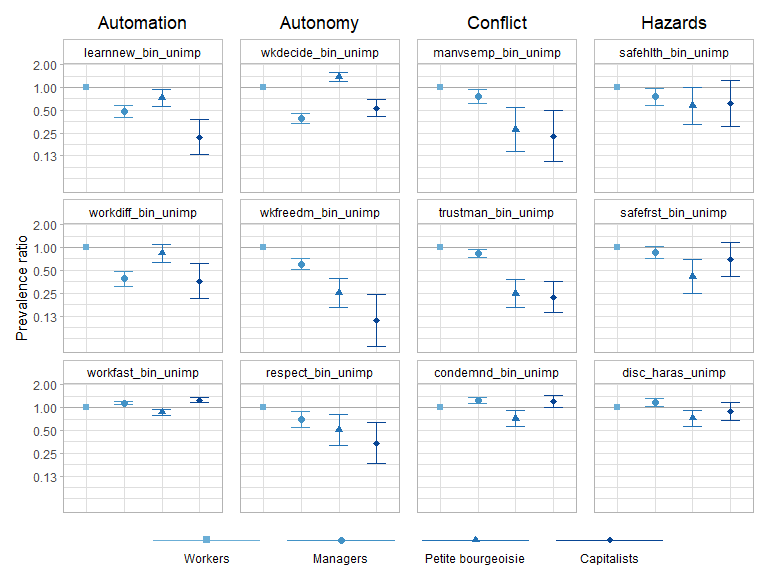

```r
#plot of estimates
(plotted(rows=c(1:9,37:39), xaxis=Class, limitsvec=c(0.049, 1.73), breaksvec=c(0.125, 0.25, 0.5, 1, 2),
        cols=brewer.pal(8, "Blues")[c(5,6,7,8)], shapes=c(15,16,17,18))  +
  plotted(rows=c(10:18,40:42), xaxis=Class, limitsvec=c(0.049, 1.73), breaksvec=c(0.125, 0.25, 0.5, 1, 2),
          cols=brewer.pal(8, "Blues")[c(5,6,7,8)], shapes=c(15,16,17,18)) +
   theme(axis.title.y=element_blank(), axis.text.y=element_blank(), axis.ticks.y=element_blank()) +
  plotted(rows=c(19:27,43:45), xaxis=Class, limitsvec=c(0.049, 1.73), breaksvec=c(0.125, 0.25, 0.5, 1, 2),
          cols=brewer.pal(8, "Blues")[c(5,6,7,8)], shapes=c(15,16,17,18)) +
   theme(axis.title.y=element_blank(), axis.text.y=element_blank(), axis.ticks.y=element_blank()) +
  plotted(rows=c(28:36, 46:48), xaxis=Class, limitsvec=c(0.049, 1.73), breaksvec=c(0.125, 0.25, 0.5, 1, 2),
          cols=brewer.pal(8, "Blues")[c(5,6,7,8)], shapes=c(15,16,17,18)) +
   theme(axis.title.y=element_blank(), axis.text.y=element_blank(), axis.ticks.y=element_blank()) +
  plot_layout(ncol=4)) /
  legends(rows=c(1:9,37:39), xaxis=Class, cols=brewer.pal(8, "Blues")[c(5,6,7,8)], shapes=c(15,16,17,18), nrow=1) +
  plot_layout(heights=c(1,0.1))
```

```r
#table of estimates
tabled(1:36, "Ref: workers")
```

Ref: workers

| QWL variable | Class | PR | Lower | Upper | Type |
| --- | --- | --- | --- | --- | --- |
| 0.48 | 0.40 | 0.59 | learnnew_bin_unimp | Managers | Automation |
| 0.73 | 0.57 | 0.93 | learnnew_bin_unimp | Petite bourgeoisie | Automation |
| 0.22 | 0.13 | 0.38 | learnnew_bin_unimp | Capitalists | Automation |
| 0.39 | 0.31 | 0.49 | workdiff_bin_unimp | Managers | Automation |
| 0.84 | 0.64 | 1.11 | workdiff_bin_unimp | Petite bourgeoisie | Automation |
| 0.36 | 0.21 | 0.61 | workdiff_bin_unimp | Capitalists | Automation |
| 1.15 | 1.10 | 1.20 | workfast_bin_unimp | Managers | Automation |
| 0.87 | 0.78 | 0.95 | workfast_bin_unimp | Petite bourgeoisie | Automation |
| 1.26 | 1.17 | 1.34 | workfast_bin_unimp | Capitalists | Automation |
| 0.39 | 0.33 | 0.45 | wkdecide_bin_unimp | Managers | Autonomy |
| 1.37 | 1.19 | 1.59 | wkdecide_bin_unimp | Petite bourgeoisie | Autonomy |
| 0.54 | 0.41 | 0.70 | wkdecide_bin_unimp | Capitalists | Autonomy |
| 0.61 | 0.51 | 0.72 | wkfreedm_bin_unimp | Managers | Autonomy |
| 0.25 | 0.16 | 0.40 | wkfreedm_bin_unimp | Petite bourgeoisie | Autonomy |
| 0.11 | 0.05 | 0.24 | wkfreedm_bin_unimp | Capitalists | Autonomy |
| 0.71 | 0.56 | 0.90 | respect_bin_unimp | Managers | Autonomy |
| 0.51 | 0.32 | 0.82 | respect_bin_unimp | Petite bourgeoisie | Autonomy |
| 0.34 | 0.18 | 0.63 | respect_bin_unimp | Capitalists | Autonomy |
| 0.77 | 0.62 | 0.95 | manvsemp_bin_unimp | Managers | Conflict |
| 0.28 | 0.14 | 0.54 | manvsemp_bin_unimp | Petite bourgeoisie | Conflict |
| 0.23 | 0.10 | 0.50 | manvsemp_bin_unimp | Capitalists | Conflict |
| 0.85 | 0.75 | 0.95 | trustman_bin_unimp | Managers | Conflict |
| 0.25 | 0.16 | 0.38 | trustman_bin_unimp | Petite bourgeoisie | Conflict |
| 0.22 | 0.14 | 0.36 | trustman_bin_unimp | Capitalists | Conflict |
| 1.23 | 1.12 | 1.36 | condemnd_bin_unimp | Managers | Conflict |
| 0.72 | 0.57 | 0.91 | condemnd_bin_unimp | Petite bourgeoisie | Conflict |
| 1.21 | 1.00 | 1.46 | condemnd_bin_unimp | Capitalists | Conflict |
| 0.75 | 0.59 | 0.96 | safehlth_bin_unimp | Managers | Hazards |
| 0.58 | 0.33 | 1.00 | safehlth_bin_unimp | Petite bourgeoisie | Hazards |
| 0.62 | 0.31 | 1.24 | safehlth_bin_unimp | Capitalists | Hazards |
| 0.87 | 0.72 | 1.05 | safefrst_bin_unimp | Managers | Hazards |
| 0.42 | 0.25 | 0.70 | safefrst_bin_unimp | Petite bourgeoisie | Hazards |
| 0.69 | 0.41 | 1.16 | safefrst_bin_unimp | Capitalists | Hazards |
| 1.17 | 1.04 | 1.31 | disc_haras_unimp | Managers | Hazards |
| 0.72 | 0.56 | 0.93 | disc_haras_unimp | Petite bourgeoisie | Hazards |
| 0.90 | 0.69 | 1.17 | disc_haras_unimp | Capitalists | Hazards |

### Gender interaction

```r
#run regression
less_adj <- mysvy(svy_dat_mi, c(24:35), "~class_gender + rcs(age, 3) + rcs(year, 3)")

#pull into matrix
regs_less <- matrix_func(12, 8, c(24:35))

#format matrix
binded <- formatted(c("Male managers", "Male petite bourgeoisie", "Male capitalists", "Female workers",
                      "Female managers", "Female petite bourgeoisie", "Female capitalists"), 12,
                    c("learnnew_bin_unimp", "wkdecide_bin_unimp", "manvsemp_bin_unimp", "safehlth_bin_unimp",
                      "workdiff_bin_unimp", "wkfreedm_bin_unimp", "trustman_bin_unimp", "safefrst_bin_unimp",
                      "workfast_bin_unimp", "respect_bin_unimp", "condemnd_bin_unimp", "disc_haras_unimp"),
                    "Male workers",
                    c("Male workers", "Male managers", "Male petite bourgeoisie", "Male capitalists",
                      "Female workers", "Female managers", "Female petite bourgeoisie", "Female capitalists"))
```

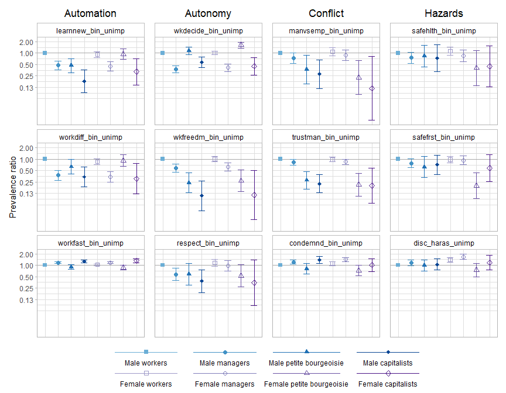

```r
#plot of estimates
(plotted(rows=c(1:21,85,89,93), xaxis=Class, limitsvec=c(0.016, 2.07), breaksvec=c(0.125, 0.25, 0.5, 1, 2),
        cols=c(brewer.pal(8, "Blues")[c(5,6,7,8)], brewer.pal(8, "Purples")[c(5,6,7,8)]), shapes=c(15,16,17,18,0,1,2,5))  +
  plotted(rows=c(22:42,86,90,94), xaxis=Class, limitsvec=c(0.016, 2.07), breaksvec=c(0.125, 0.25, 0.5, 1, 2),
          cols=c(brewer.pal(8, "Blues")[c(5,6,7,8)], brewer.pal(8, "Purples")[c(5,6,7,8)]), shapes=c(15,16,17,18,0,1,2,5)) +
   theme(axis.title.y=element_blank(), axis.text.y=element_blank(), axis.ticks.y=element_blank()) +
  plotted(rows=c(43:63,87,91,95), xaxis=Class, limitsvec=c(0.016, 2.07), breaksvec=c(0.125, 0.25, 0.5, 1, 2),
          cols=c(brewer.pal(8, "Blues")[c(5,6,7,8)], brewer.pal(8, "Purples")[c(5,6,7,8)]), shapes=c(15,16,17,18,0,1,2,5)) +
   theme(axis.title.y=element_blank(), axis.text.y=element_blank(), axis.ticks.y=element_blank()) +
  plotted(rows=c(64:84,88,92,96), xaxis=Class, limitsvec=c(0.016, 2.07), breaksvec=c(0.125, 0.25, 0.5, 1, 2),
          cols=c(brewer.pal(8, "Blues")[c(5,6,7,8)], brewer.pal(8, "Purples")[c(5,6,7,8)]), shapes=c(15,16,17,18,0,1,2,5)) +
   theme(axis.title.y=element_blank(), axis.text.y=element_blank(), axis.ticks.y=element_blank()) +
  plot_layout(ncol=4)) /
  legends(rows=c(1:21,85,89,93), xaxis=Class, cols=c(brewer.pal(8, "Blues")[c(5,6,7,8)], brewer.pal(8, "Purples")[c(5,6,7,8)]),
          shapes=c(15,16,17,18,0,1,2,5), nrow=2) +
  plot_layout(heights=c(1,0.15))
```

```r
#table of estimates
tabled(1:84, "Ref: male workers")
```

Ref: male workers

| QWL variable | Class | PR | Lower | Upper | Type |
| --- | --- | --- | --- | --- | --- |
| 0.48 | 0.36 | 0.62 | learnnew_bin_unimp | Male managers | Automation |
| 0.47 | 0.31 | 0.72 | learnnew_bin_unimp | Male petite bourgeoisie | Automation |
| 0.18 | 0.09 | 0.36 | learnnew_bin_unimp | Male capitalists | Automation |
| 0.92 | 0.77 | 1.10 | learnnew_bin_unimp | Female workers | Automation |
| 0.45 | 0.33 | 0.60 | learnnew_bin_unimp | Female managers | Automation |
| 0.93 | 0.67 | 1.28 | learnnew_bin_unimp | Female petite bourgeoisie | Automation |
| 0.32 | 0.15 | 0.72 | learnnew_bin_unimp | Female capitalists | Automation |
| 0.38 | 0.28 | 0.51 | workdiff_bin_unimp | Male managers | Automation |
| 0.63 | 0.40 | 0.99 | workdiff_bin_unimp | Male petite bourgeoisie | Automation |
| 0.34 | 0.18 | 0.63 | workdiff_bin_unimp | Male capitalists | Automation |
| 0.86 | 0.72 | 1.03 | workdiff_bin_unimp | Female workers | Automation |
| 0.34 | 0.25 | 0.48 | workdiff_bin_unimp | Female managers | Automation |
| 0.92 | 0.65 | 1.30 | workdiff_bin_unimp | Female petite bourgeoisie | Automation |
| 0.30 | 0.12 | 0.77 | workdiff_bin_unimp | Female capitalists | Automation |
| 1.18 | 1.11 | 1.24 | workfast_bin_unimp | Male managers | Automation |
| 0.89 | 0.77 | 1.03 | workfast_bin_unimp | Male petite bourgeoisie | Automation |
| 1.27 | 1.16 | 1.39 | workfast_bin_unimp | Male capitalists | Automation |
| 1.04 | 0.98 | 1.09 | workfast_bin_unimp | Female workers | Automation |
| 1.17 | 1.10 | 1.25 | workfast_bin_unimp | Female managers | Automation |
| 0.87 | 0.76 | 1.01 | workfast_bin_unimp | Female petite bourgeoisie | Automation |
| 1.31 | 1.16 | 1.49 | workfast_bin_unimp | Female capitalists | Automation |
| 0.38 | 0.30 | 0.47 | wkdecide_bin_unimp | Male managers | Autonomy |
| 1.15 | 0.92 | 1.44 | wkdecide_bin_unimp | Male petite bourgeoisie | Autonomy |
| 0.57 | 0.41 | 0.79 | wkdecide_bin_unimp | Male capitalists | Autonomy |
| 1.02 | 0.91 | 1.15 | wkdecide_bin_unimp | Female workers | Autonomy |
| 0.41 | 0.33 | 0.52 | wkdecide_bin_unimp | Female managers | Autonomy |
| 1.63 | 1.36 | 1.96 | wkdecide_bin_unimp | Female petite bourgeoisie | Autonomy |
| 0.45 | 0.27 | 0.77 | wkdecide_bin_unimp | Female capitalists | Autonomy |
| 0.59 | 0.46 | 0.76 | wkfreedm_bin_unimp | Male managers | Autonomy |
| 0.24 | 0.13 | 0.43 | wkfreedm_bin_unimp | Male petite bourgeoisie | Autonomy |

[output cut: 54 more lines]

### Race interaction (white/POC)

Cell sizes too small among Black capitalists to divide up race variable even further.

```r
#run regression
less_adj <- mysvy(svy_dat_mi, c(24:35), "~class_poc + rcs(age, 3) + rcs(year, 3)")

#pull into matrix
regs_less <- matrix_func(12, 8, c(24:35))

#format matrix
binded <- formatted(c("White managers", "White petite bourgeoisie", "White capitalists",
                      "POC workers", "POC managers", "POC petite bourgeoisie", "POC capitalists"), 12,
                    c("learnnew_bin_unimp", "wkdecide_bin_unimp", "manvsemp_bin_unimp", "safehlth_bin_unimp",
                      "workdiff_bin_unimp", "wkfreedm_bin_unimp", "trustman_bin_unimp", "safefrst_bin_unimp",
                      "workfast_bin_unimp", "respect_bin_unimp", "condemnd_bin_unimp", "disc_haras_unimp"),
                    "White workers",
                    c("White workers", "White managers", "White petite bourgeoisie", "White capitalists",
                      "POC workers", "POC managers", "POC petite bourgeoisie", "POC capitalists"))
```

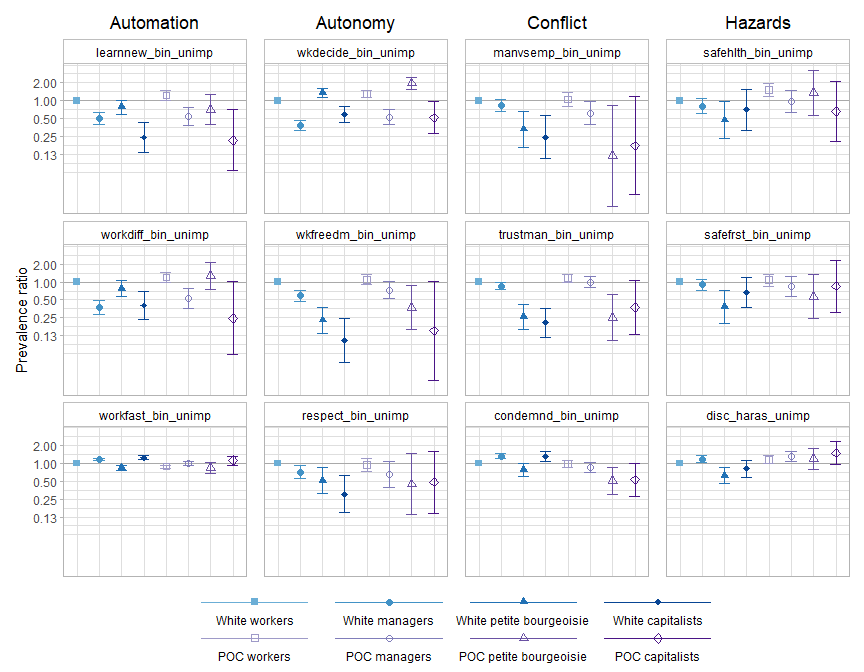

```r
#plot of estimates
(plotted(rows=c(1:21,85,89,93), xaxis=Class, limitsvec=c(0.016, 3.24), breaksvec=c(0.125, 0.25, 0.5, 1, 2),
        cols=c(brewer.pal(8, "Blues")[c(5,6,7,8)], brewer.pal(8, "Purples")[c(5,6,7,8)]), shapes=c(15,16,17,18,0,1,2,5))  +
  plotted(rows=c(22:42,86,90,94), xaxis=Class, limitsvec=c(0.016, 3.24), breaksvec=c(0.125, 0.25, 0.5, 1, 2),
          cols=c(brewer.pal(8, "Blues")[c(5,6,7,8)], brewer.pal(8, "Purples")[c(5,6,7,8)]), shapes=c(15,16,17,18,0,1,2,5)) +
   theme(axis.title.y=element_blank(), axis.text.y=element_blank(), axis.ticks.y=element_blank()) +
  plotted(rows=c(43:63,87,91,95), xaxis=Class, limitsvec=c(0.016, 3.24), breaksvec=c(0.125, 0.25, 0.5, 1, 2),
          cols=c(brewer.pal(8, "Blues")[c(5,6,7,8)], brewer.pal(8, "Purples")[c(5,6,7,8)]), shapes=c(15,16,17,18,0,1,2,5)) +
   theme(axis.title.y=element_blank(), axis.text.y=element_blank(), axis.ticks.y=element_blank()) +
  plotted(rows=c(64:84,88,92,96), xaxis=Class, limitsvec=c(0.016, 3.24), breaksvec=c(0.125, 0.25, 0.5, 1, 2),
          cols=c(brewer.pal(8, "Blues")[c(5,6,7,8)], brewer.pal(8, "Purples")[c(5,6,7,8)]), shapes=c(15,16,17,18,0,1,2,5)) +
   theme(axis.title.y=element_blank(), axis.text.y=element_blank(), axis.ticks.y=element_blank()) +
  plot_layout(ncol=4)) /
  legends(rows=c(1:21,85,89,93), xaxis=Class, cols=c(brewer.pal(8, "Blues")[c(5,6,7,8)], brewer.pal(8, "Purples")[c(5,6,7,8)]),
          shapes=c(15,16,17,18,0,1,2,5), nrow=2) +
  plot_layout(heights=c(1,0.15))
```

```r
#table of estimates
tabled(1:84, "Ref: white workers")
```

Ref: white workers

| QWL variable | Class | PR | Lower | Upper | Type |
| --- | --- | --- | --- | --- | --- |
| 0.50 | 0.40 | 0.63 | learnnew_bin_unimp | White managers | Automation |
| 0.78 | 0.60 | 1.02 | learnnew_bin_unimp | White petite bourgeoisie | Automation |
| 0.24 | 0.13 | 0.43 | learnnew_bin_unimp | White capitalists | Automation |
| 1.23 | 1.03 | 1.47 | learnnew_bin_unimp | POC workers | Automation |
| 0.55 | 0.39 | 0.78 | learnnew_bin_unimp | POC managers | Automation |
| 0.70 | 0.39 | 1.26 | learnnew_bin_unimp | POC petite bourgeoisie | Automation |
| 0.21 | 0.07 | 0.70 | learnnew_bin_unimp | POC capitalists | Automation |
| 0.37 | 0.28 | 0.49 | workdiff_bin_unimp | White managers | Automation |
| 0.78 | 0.57 | 1.06 | workdiff_bin_unimp | White petite bourgeoisie | Automation |
| 0.40 | 0.23 | 0.70 | workdiff_bin_unimp | White capitalists | Automation |
| 1.19 | 0.98 | 1.45 | workdiff_bin_unimp | POC workers | Automation |
| 0.53 | 0.36 | 0.78 | workdiff_bin_unimp | POC managers | Automation |
| 1.28 | 0.76 | 2.13 | workdiff_bin_unimp | POC petite bourgeoisie | Automation |
| 0.24 | 0.06 | 1.01 | workdiff_bin_unimp | POC capitalists | Automation |
| 1.15 | 1.10 | 1.20 | workfast_bin_unimp | White managers | Automation |
| 0.84 | 0.75 | 0.94 | workfast_bin_unimp | White petite bourgeoisie | Automation |
| 1.24 | 1.15 | 1.34 | workfast_bin_unimp | White capitalists | Automation |
| 0.88 | 0.83 | 0.94 | workfast_bin_unimp | POC workers | Automation |
| 1.00 | 0.92 | 1.08 | workfast_bin_unimp | POC managers | Automation |
| 0.83 | 0.68 | 1.03 | workfast_bin_unimp | POC petite bourgeoisie | Automation |
| 1.12 | 0.94 | 1.33 | workfast_bin_unimp | POC capitalists | Automation |
| 0.39 | 0.32 | 0.47 | wkdecide_bin_unimp | White managers | Autonomy |
| 1.35 | 1.14 | 1.60 | wkdecide_bin_unimp | White petite bourgeoisie | Autonomy |
| 0.59 | 0.44 | 0.78 | wkdecide_bin_unimp | White capitalists | Autonomy |
| 1.31 | 1.14 | 1.49 | wkdecide_bin_unimp | POC workers | Autonomy |
| 0.53 | 0.40 | 0.70 | wkdecide_bin_unimp | POC managers | Autonomy |
| 1.97 | 1.57 | 2.47 | wkdecide_bin_unimp | POC petite bourgeoisie | Autonomy |
| 0.52 | 0.28 | 0.96 | wkdecide_bin_unimp | POC capitalists | Autonomy |
| 0.59 | 0.48 | 0.72 | wkfreedm_bin_unimp | White managers | Autonomy |
| 0.23 | 0.14 | 0.38 | wkfreedm_bin_unimp | White petite bourgeoisie | Autonomy |

[output cut: 54 more lines]

## Gender, race, and QWL among workers

Prevalence of bad category of each binary QWL variable among each minoritized gender, racial, or gender-racial group of workers relative to the prevalence among male, white, or white male workers adjusted for age and year with restricted cubic splines.

### Gender

```r
#run regression
less_adj <- mysvy(subset(svy_dat_mi, class=="Workers"), 24:35, "~relevel(as.factor(sex), ref='male') + rcs(age, 3) + rcs(year, 3)")

#pull into matrix
regs_less <- matrix_func(12, 3, 24:35)

#for some reason function doesn't work properly when only extract one coefficient so we need to delete every other row from regs_less to get df formatted correctly
nth.delete <- function(dataframe, n)dataframe[-(seq(n,to=nrow(dataframe),by=n)),]
regs_less <- nth.delete(regs_less, 2)

#format matrix
binded <- formatted(c("Female"), 12,
                    c("learnnew_bin_unimp", "wkdecide_bin_unimp", "manvsemp_bin_unimp", "safehlth_bin_unimp",
                      "workdiff_bin_unimp", "wkfreedm_bin_unimp", "trustman_bin_unimp", "safefrst_bin_unimp",
                      "workfast_bin_unimp", "respect_bin_unimp", "condemnd_bin_unimp", "disc_haras_unimp"),
                    "Male",
                    c("Male", "Female"))
```

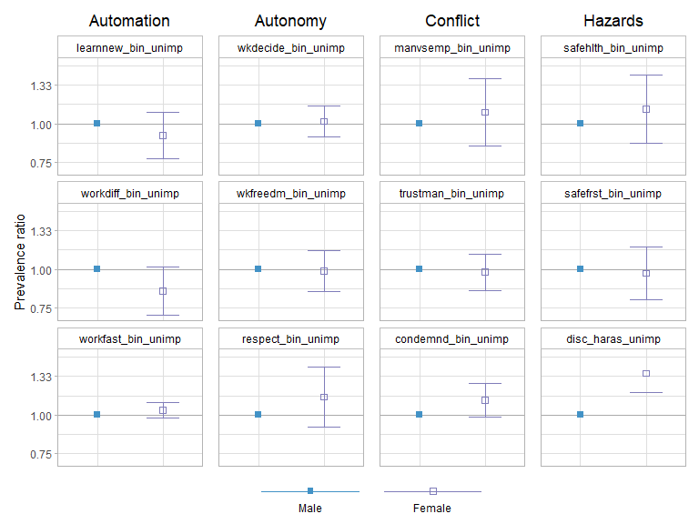

```r
#plot of estimates
(plotted(rows=c(1:3,13,17,21), xaxis=Class, limitsvec=c(0.71,1.57), breaksvec=c(0.75, 1, 1.3333333, 1.333333^2),
        cols=c(brewer.pal(8, "Blues")[c(6)], brewer.pal(8, "Purples")[c(6)]), shapes=c(15, 0))  +
  plotted(rows=c(4:6,14,18,22), xaxis=Class, limitsvec=c(0.71,1.57), breaksvec=c(0.75, 1, 1.3333333, 1.333333^2),
          cols=c(brewer.pal(8, "Blues")[c(6)], brewer.pal(8, "Purples")[c(6)]), shapes=c(15, 0)) +
   theme(axis.title.y=element_blank(), axis.text.y=element_blank(), axis.ticks.y=element_blank()) +
  plotted(rows=c(7:9,15,19,23), xaxis=Class, limitsvec=c(0.71,1.57), breaksvec=c(0.75, 1, 1.3333333, 1.333333^2),
          cols=c(brewer.pal(8, "Blues")[c(6)], brewer.pal(8, "Purples")[c(6)]), shapes=c(15, 0)) +
   theme(axis.title.y=element_blank(), axis.text.y=element_blank(), axis.ticks.y=element_blank()) +
  plotted(rows=c(10:12,16,20,24), xaxis=Class, limitsvec=c(0.71,1.57), breaksvec=c(0.75, 1, 1.3333333, 1.333333^2),
          cols=c(brewer.pal(8, "Blues")[c(6)], brewer.pal(8, "Purples")[c(6)]), shapes=c(15, 0)) +
   theme(axis.title.y=element_blank(), axis.text.y=element_blank(), axis.ticks.y=element_blank()) +
  plot_layout(ncol=4)) /
  legends(rows=c(1,13), xaxis=Class, cols=c(brewer.pal(8, "Blues")[c(6)], brewer.pal(8, "Purples")[c(6)]), shapes=c(15, 0), nrow=1) +
  plot_layout(heights=c(1,0.1))
```

```r
#table of estimates
tabled(1:12, "Ref: male")
```

Ref: male

| QWL variable | Class | PR | Lower | Upper | Type |
| --- | --- | --- | --- | --- | --- |
| 0.92 | 0.77 | 1.09 | learnnew_bin_unimp | Female | Automation |
| 0.85 | 0.71 | 1.02 | workdiff_bin_unimp | Female | Automation |
| 1.04 | 0.98 | 1.10 | workfast_bin_unimp | Female | Automation |
| 1.02 | 0.91 | 1.14 | wkdecide_bin_unimp | Female | Autonomy |
| 0.99 | 0.85 | 1.15 | wkfreedm_bin_unimp | Female | Autonomy |
| 1.14 | 0.91 | 1.43 | respect_bin_unimp | Female | Autonomy |
| 1.09 | 0.85 | 1.40 | manvsemp_bin_unimp | Female | Conflict |
| 0.98 | 0.86 | 1.12 | trustman_bin_unimp | Female | Conflict |
| 1.11 | 0.98 | 1.26 | condemnd_bin_unimp | Female | Conflict |
| 1.12 | 0.87 | 1.44 | safehlth_bin_unimp | Female | Hazards |
| 0.97 | 0.80 | 1.19 | safefrst_bin_unimp | Female | Hazards |
| 1.36 | 1.18 | 1.57 | disc_haras_unimp | Female | Hazards |

### Race

```r
#run regression
less_adj <- mysvy(subset(svy_dat_mi, class=="Workers"), 24:35, "~race + rcs(age, 3) + rcs(year, 3)")

#pull into matrix
regs_less <- matrix_func(12, 3, 24:35)

#format matrix
binded <- formatted(c("Black", "Other"), 12,
                    c("learnnew_bin_unimp", "wkdecide_bin_unimp", "manvsemp_bin_unimp", "safehlth_bin_unimp",
                      "workdiff_bin_unimp", "wkfreedm_bin_unimp", "trustman_bin_unimp", "safefrst_bin_unimp",
                      "workfast_bin_unimp", "respect_bin_unimp", "condemnd_bin_unimp", "disc_haras_unimp"),
                    "White",
                    c("White", "Black", "Other"))
```

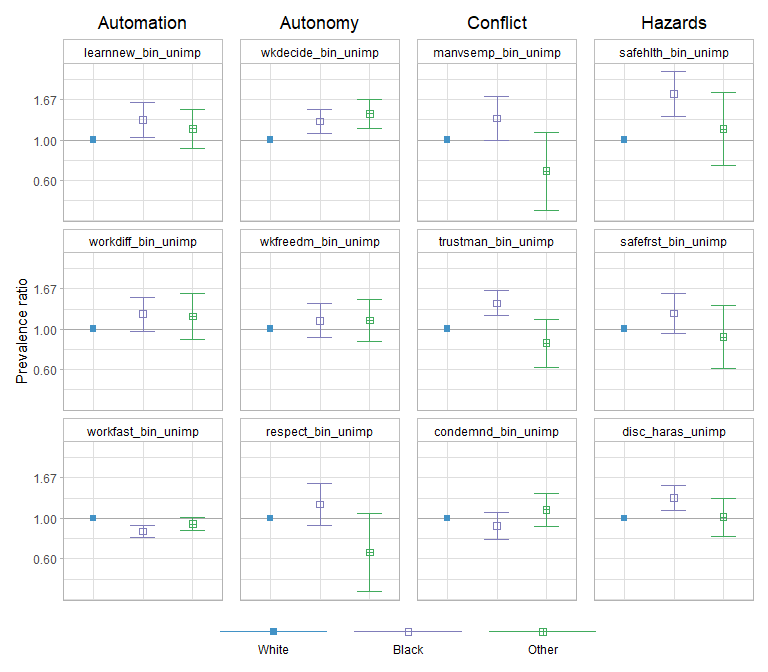

```r
#plot of estimates
(plotted(rows=c(1:6,25,29,33), xaxis=Class, limitsvec=c(0.39, 2.4), breaksvec=c(0.6, 1, 1.666667, 1.666667^2),
        cols=c(brewer.pal(8, "Blues")[c(6)], brewer.pal(8, "Purples")[c(6)], brewer.pal(8, "Greens")[c(6)]), shapes=c(15, 0, 12))  +
  plotted(rows=c(7:12,26,30,34), xaxis=Class, limitsvec=c(0.39, 2.4), breaksvec=c(0.6, 1, 1.666667, 1.666667^2),
          cols=c(brewer.pal(8, "Blues")[c(6)], brewer.pal(8, "Purples")[c(6)], brewer.pal(8, "Greens")[c(6)]), shapes=c(15, 0, 12)) +
    theme(axis.title.y=element_blank(), axis.text.y=element_blank(), axis.ticks.y=element_blank()) +
  plotted(rows=c(13:18,27,31,35), xaxis=Class, limitsvec=c(0.39, 2.4), breaksvec=c(0.6, 1, 1.666667, 1.666667^2),
          cols=c(brewer.pal(8, "Blues")[c(6)], brewer.pal(8, "Purples")[c(6)], brewer.pal(8, "Greens")[c(6)]), shapes=c(15, 0, 12)) +
    theme(axis.title.y=element_blank(), axis.text.y=element_blank(), axis.ticks.y=element_blank()) +
  plotted(rows=c(19:24,28,32,36), xaxis=Class, limitsvec=c(0.39, 2.4), breaksvec=c(0.6, 1, 1.666667, 1.666667^2),
          cols=c(brewer.pal(8, "Blues")[c(6)], brewer.pal(8, "Purples")[c(6)], brewer.pal(8, "Greens")[c(6)]), shapes=c(15, 0, 12)) +
    theme(axis.title.y=element_blank(), axis.text.y=element_blank(), axis.ticks.y=element_blank()) +
  plot_layout(ncol=4)) /
  legends(rows=c(1:2,25), xaxis=Class, cols=c(brewer.pal(8, "Blues")[c(6)], brewer.pal(8, "Purples")[c(6)], brewer.pal(8, "Greens")[c(6)]),
          shapes=c(15, 0, 12), nrow=1) +
  plot_layout(heights=c(1,0.1))
```

```r
#table of estimates
tabled(1:24, "Ref: white")
```

Ref: white

| QWL variable | Class | PR | Lower | Upper | Type |
| --- | --- | --- | --- | --- | --- |
| 1.29 | 1.04 | 1.60 | learnnew_bin_unimp | Black | Automation |
| 1.15 | 0.90 | 1.47 | learnnew_bin_unimp | Other | Automation |
| 1.21 | 0.98 | 1.50 | workdiff_bin_unimp | Black | Automation |
| 1.17 | 0.88 | 1.57 | workdiff_bin_unimp | Other | Automation |
| 0.85 | 0.78 | 0.92 | workfast_bin_unimp | Black | Automation |
| 0.93 | 0.86 | 1.01 | workfast_bin_unimp | Other | Automation |
| 1.26 | 1.08 | 1.48 | wkdecide_bin_unimp | Black | Autonomy |
| 1.39 | 1.16 | 1.68 | wkdecide_bin_unimp | Other | Autonomy |
| 1.11 | 0.90 | 1.38 | wkfreedm_bin_unimp | Black | Autonomy |
| 1.12 | 0.85 | 1.46 | wkfreedm_bin_unimp | Other | Autonomy |
| 1.19 | 0.91 | 1.56 | respect_bin_unimp | Black | Autonomy |
| 0.65 | 0.40 | 1.07 | respect_bin_unimp | Other | Autonomy |
| 1.31 | 0.99 | 1.74 | manvsemp_bin_unimp | Black | Conflict |
| 0.67 | 0.41 | 1.10 | manvsemp_bin_unimp | Other | Conflict |
| 1.39 | 1.18 | 1.62 | trustman_bin_unimp | Black | Conflict |
| 0.84 | 0.62 | 1.14 | trustman_bin_unimp | Other | Conflict |
| 0.91 | 0.76 | 1.07 | condemnd_bin_unimp | Black | Conflict |
| 1.11 | 0.90 | 1.38 | condemnd_bin_unimp | Other | Conflict |
| 1.80 | 1.35 | 2.39 | safehlth_bin_unimp | Black | Hazards |
| 1.15 | 0.72 | 1.83 | safehlth_bin_unimp | Other | Hazards |
| 1.22 | 0.94 | 1.57 | safefrst_bin_unimp | Black | Hazards |
| 0.91 | 0.61 | 1.36 | safefrst_bin_unimp | Other | Hazards |
| 1.29 | 1.10 | 1.51 | disc_haras_unimp | Black | Hazards |
| 1.01 | 0.80 | 1.29 | disc_haras_unimp | Other | Hazards |

### Gender-race interaction

```r
#run regression
less_adj <- mysvy(subset(svy_dat_mi, class=="Workers"), 24:35, "~race_gender + rcs(age, 3) + rcs(year, 3)")

#pull into matrix
regs_less <- matrix_func(12, 6, 24:35)

#format matrix
binded <- formatted(c("White female", "Black male", "Black female", "Other male", "Other female"), 12,
                    c("learnnew_bin_unimp", "wkdecide_bin_unimp", "manvsemp_bin_unimp", "safehlth_bin_unimp",
                      "workdiff_bin_unimp", "wkfreedm_bin_unimp", "trustman_bin_unimp", "safefrst_bin_unimp",
                      "workfast_bin_unimp", "respect_bin_unimp", "condemnd_bin_unimp", "disc_haras_unimp"),
                     "White male",
                    c("White male", "White female", "Black male", "Black female", "Other male", "Other female"))
```

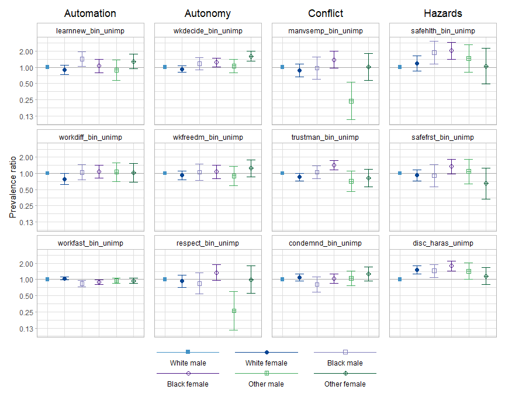

```r
#plot estimates
(plotted(rows=c(1:15,61,65,69), xaxis=Class, limitsvec=c(0.1, 3.07), breaksvec=c(0.125, 0.25, 0.5, 1, 2),
        cols=c(brewer.pal(8, "Blues")[c(6,8)], brewer.pal(8, "Purples")[c(6,8)], brewer.pal(8, "Greens")[c(6,8)]), shapes=c(15, 16, 0, 1, 12, 10))  +
  plotted(rows=c(16:30,62,66,70), xaxis=Class, limitsvec=c(0.1, 3.07), breaksvec=c(0.125, 0.25, 0.5, 1, 2),
          cols=c(brewer.pal(8, "Blues")[c(6,8)], brewer.pal(8, "Purples")[c(6,8)], brewer.pal(8, "Greens")[c(6,8)]), shapes=c(15, 16, 0, 1, 12, 10)) +
    theme(axis.title.y=element_blank(), axis.text.y=element_blank(), axis.ticks.y=element_blank()) +
  plotted(rows=c(31:45,63,67,71), xaxis=Class, limitsvec=c(0.1, 3.07), breaksvec=c(0.125, 0.25, 0.5, 1, 2),
          cols=c(brewer.pal(8, "Blues")[c(6,8)], brewer.pal(8, "Purples")[c(6,8)], brewer.pal(8, "Greens")[c(6,8)]), shapes=c(15, 16, 0, 1, 12, 10)) +
    theme(axis.title.y=element_blank(), axis.text.y=element_blank(), axis.ticks.y=element_blank()) +
  plotted(rows=c(46:60,64,68,72), xaxis=Class, limitsvec=c(0.1, 3.07), breaksvec=c(0.125, 0.25, 0.5, 1, 2),
          cols=c(brewer.pal(8, "Blues")[c(6,8)], brewer.pal(8, "Purples")[c(6,8)], brewer.pal(8, "Greens")[c(6,8)]), shapes=c(15, 16, 0, 1, 12, 10)) +
    theme(axis.title.y=element_blank(), axis.text.y=element_blank(), axis.ticks.y=element_blank()) +
  plot_layout(ncol=4)) /
  legends(rows=c(1:5,61), xaxis=Class, cols=c(brewer.pal(8, "Blues")[c(6,8)], brewer.pal(8, "Purples")[c(6,8)], brewer.pal(8, "Greens")[c(6,8)]),
          shapes=c(15, 16, 0, 1, 12, 10), nrow=2) +
  plot_layout(heights=c(1,0.15))
```

```r
#table of estimates
tabled(1:60, "Ref: white male")
```

Ref: white male

| QWL variable | Class | PR | Lower | Upper | Type |
| --- | --- | --- | --- | --- | --- |
| 0.90 | 0.73 | 1.10 | learnnew_bin_unimp | White female | Automation |
| 1.44 | 1.05 | 1.97 | learnnew_bin_unimp | Black male | Automation |
| 1.06 | 0.80 | 1.41 | learnnew_bin_unimp | Black female | Automation |
| 0.89 | 0.58 | 1.37 | learnnew_bin_unimp | Other male | Automation |
| 1.28 | 0.94 | 1.75 | learnnew_bin_unimp | Other female | Automation |
| 0.79 | 0.63 | 1.00 | workdiff_bin_unimp | White female | Automation |
| 1.05 | 0.76 | 1.45 | workdiff_bin_unimp | Black male | Automation |
| 1.09 | 0.82 | 1.44 | workdiff_bin_unimp | Black female | Automation |
| 1.06 | 0.71 | 1.58 | workdiff_bin_unimp | Other male | Automation |
| 1.02 | 0.68 | 1.52 | workdiff_bin_unimp | Other female | Automation |
| 1.04 | 0.98 | 1.11 | workfast_bin_unimp | White female | Automation |
| 0.84 | 0.73 | 0.97 | workfast_bin_unimp | Black male | Automation |
| 0.89 | 0.80 | 0.98 | workfast_bin_unimp | Black female | Automation |
| 0.95 | 0.85 | 1.07 | workfast_bin_unimp | Other male | Automation |
| 0.95 | 0.84 | 1.07 | workfast_bin_unimp | Other female | Automation |
| 0.93 | 0.80 | 1.07 | wkdecide_bin_unimp | White female | Autonomy |
| 1.17 | 0.90 | 1.51 | wkdecide_bin_unimp | Black male | Autonomy |
| 1.24 | 1.03 | 1.50 | wkdecide_bin_unimp | Black female | Autonomy |
| 1.06 | 0.80 | 1.42 | wkdecide_bin_unimp | Other male | Autonomy |
| 1.62 | 1.30 | 2.01 | wkdecide_bin_unimp | Other female | Autonomy |
| 0.92 | 0.77 | 1.12 | wkfreedm_bin_unimp | White female | Autonomy |
| 1.06 | 0.74 | 1.50 | wkfreedm_bin_unimp | Black male | Autonomy |
| 1.07 | 0.81 | 1.43 | wkfreedm_bin_unimp | Black female | Autonomy |
| 0.90 | 0.60 | 1.36 | wkfreedm_bin_unimp | Other male | Autonomy |
| 1.24 | 0.86 | 1.78 | wkfreedm_bin_unimp | Other female | Autonomy |
| 0.93 | 0.72 | 1.21 | respect_bin_unimp | White female | Autonomy |
| 0.85 | 0.54 | 1.34 | respect_bin_unimp | Black male | Autonomy |
| 1.35 | 0.97 | 1.88 | respect_bin_unimp | Black female | Autonomy |
| 0.26 | 0.11 | 0.60 | respect_bin_unimp | Other male | Autonomy |
| 0.99 | 0.55 | 1.78 | respect_bin_unimp | Other female | Autonomy |
| 0.87 | 0.66 | 1.16 | manvsemp_bin_unimp | White female | Conflict |
| 0.96 | 0.60 | 1.55 | manvsemp_bin_unimp | Black male | Conflict |
| 1.39 | 0.96 | 2.01 | manvsemp_bin_unimp | Black female | Conflict |
| 0.24 | 0.11 | 0.53 | manvsemp_bin_unimp | Other male | Conflict |
| 1.02 | 0.57 | 1.83 | manvsemp_bin_unimp | Other female | Conflict |
| 0.85 | 0.73 | 1.00 | trustman_bin_unimp | White female | Conflict |
| 1.05 | 0.80 | 1.38 | trustman_bin_unimp | Black male | Conflict |
| 1.42 | 1.18 | 1.72 | trustman_bin_unimp | Black female | Conflict |
| 0.71 | 0.46 | 1.10 | trustman_bin_unimp | Other male | Conflict |
| 0.83 | 0.57 | 1.21 | trustman_bin_unimp | Other female | Conflict |
| 1.08 | 0.93 | 1.26 | condemnd_bin_unimp | White female | Conflict |
| 0.81 | 0.59 | 1.11 | condemnd_bin_unimp | Black male | Conflict |
| 1.04 | 0.84 | 1.27 | condemnd_bin_unimp | Black female | Conflict |
| 1.05 | 0.77 | 1.44 | condemnd_bin_unimp | Other male | Conflict |
| 1.27 | 0.95 | 1.70 | condemnd_bin_unimp | Other female | Conflict |
| 1.18 | 0.85 | 1.63 | safehlth_bin_unimp | White female | Hazards |
| 1.89 | 1.16 | 3.07 | safehlth_bin_unimp | Black male | Hazards |
| 2.04 | 1.41 | 2.94 | safehlth_bin_unimp | Black female | Hazards |
| 1.47 | 0.81 | 2.64 | safehlth_bin_unimp | Other male | Hazards |
| 1.06 | 0.49 | 2.29 | safehlth_bin_unimp | Other female | Hazards |
| 0.93 | 0.73 | 1.18 | safefrst_bin_unimp | White female | Hazards |
| 0.91 | 0.57 | 1.46 | safefrst_bin_unimp | Black male | Hazards |
| 1.34 | 0.98 | 1.83 | safefrst_bin_unimp | Black female | Hazards |
| 1.09 | 0.65 | 1.84 | safefrst_bin_unimp | Other male | Hazards |
| 0.65 | 0.34 | 1.25 | safefrst_bin_unimp | Other female | Hazards |
| 1.51 | 1.28 | 1.79 | disc_haras_unimp | White female | Hazards |
| 1.45 | 1.10 | 1.90 | disc_haras_unimp | Black male | Hazards |
| 1.79 | 1.44 | 2.22 | disc_haras_unimp | Black female | Hazards |
| 1.43 | 1.01 | 2.02 | disc_haras_unimp | Other male | Hazards |
| 1.16 | 0.80 | 1.67 | disc_haras_unimp | Other female | Hazards |

# Appendix

## How many employees do PBs and capitalists typically identify as having?

Note that the numemps variable wasn’t asked in 2002, which is why we aren’t using it for our primary analyses. Note also that numemps was only asked of people who identified as self-employed, which further supports our use of the self-employed variable to identify owners.

```r
#run on unimputed data
dat %>%
  filter(year !=2002 & c(class=="Capitalists" | class=="Petit bourgeoisie")) %>%
  group_by(class) %>%
  summarise(mean_emps=round(mean(as.numeric(numemps), na.rm=T),1),
            median_emps=round(median(as.numeric(numemps), na.rm=T),1),
            lower_IQR=round(quantile(as.numeric(numemps), 0.25, na.rm=T),1),
            upper_IQR=round(quantile(as.numeric(numemps), 0.75, na.rm=T),1)) %>%
  kable() %>%
  kable_styling("striped") %>%
  scroll_box(width = "100%", height = "250px")
```

| class | mean_emps | median_emps | lower_IQR | upper_IQR |
| --- | --- | --- | --- | --- |
| Petit bourgeoisie | 0.2 | 0 | 0 | 0 |
| Capitalists | 6.0 | 2 | 0 | 6 |

## Imputation convergence plots

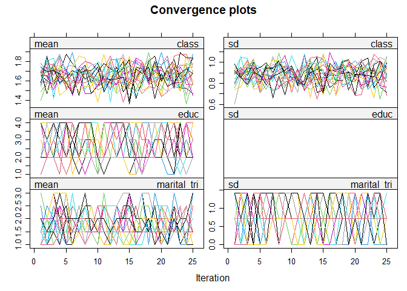

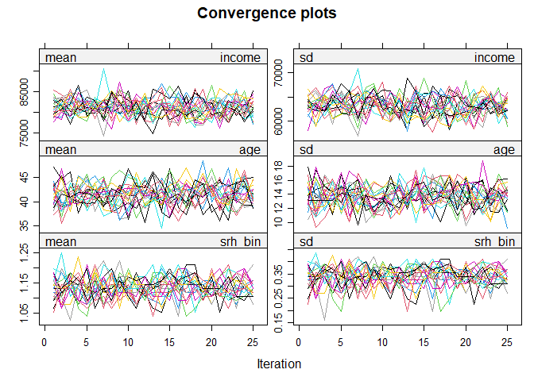

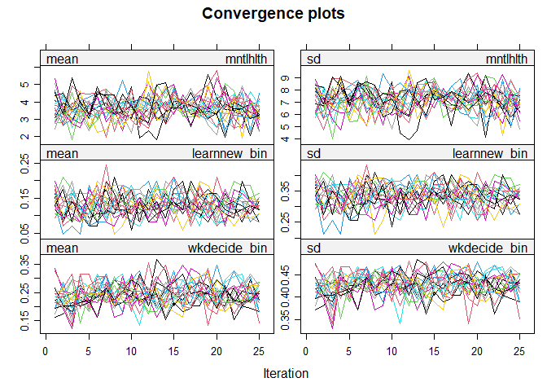

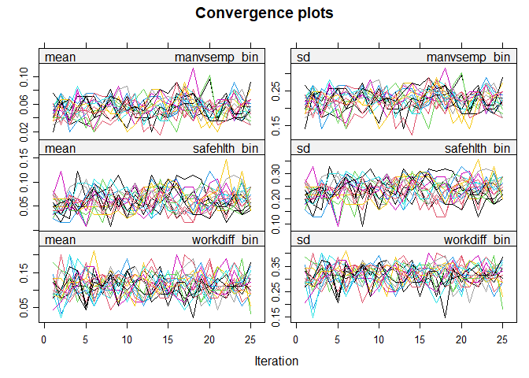

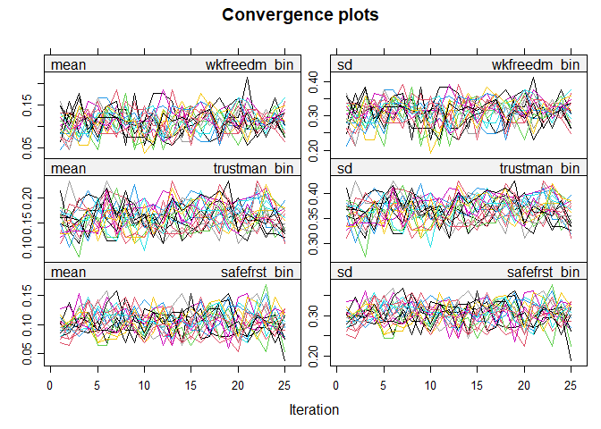

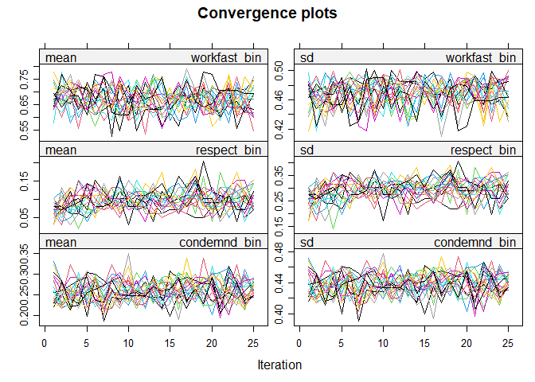

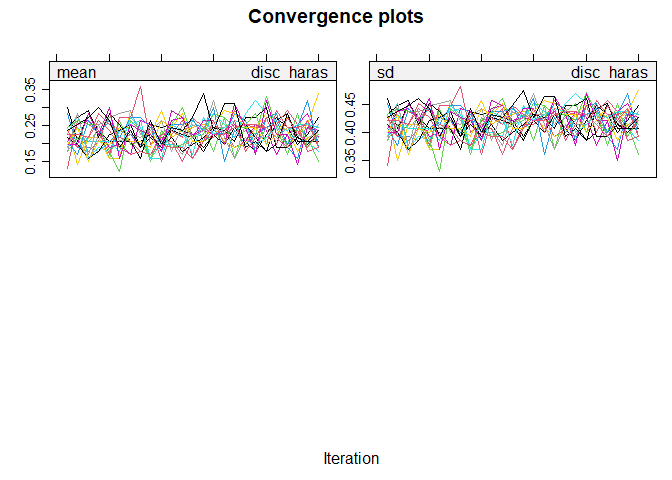

```r
plot(imp_merged, y=c('class', 'educ', 'marital_tri', 'income', 'age', "srh_bin", "mntlhlth", "learnnew_bin", "wkdecide_bin", "manvsemp_bin", "safehlth_bin", "workdiff_bin", "wkfreedm_bin", "trustman_bin", "safefrst_bin",  "workfast_bin", "respect_bin", "condemnd_bin", "disc_haras"), main='Convergence plots')
```